# 2018 Statistics Midterm Exam1

地理二 b06208001 龔泓愷

2018年10月17日

# Q1

```r
Q1 <- c(196,212,200,249,206,178,184,198,160,182,198,182,222,198,188,166,204,178,164,230)
```

1. Draw a histogram of these data. Make the bars cover intervals of cholesterol that are 10 wide.

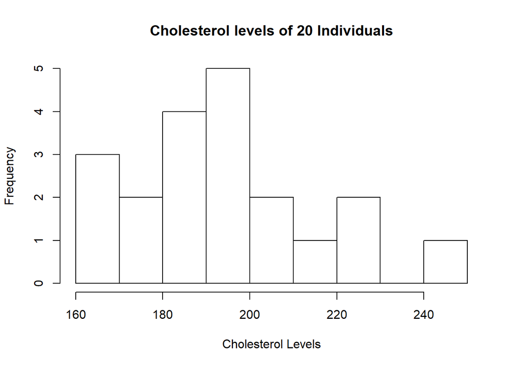

```r
hist(Q1, breaks = 10, main = 'Cholesterol levels of 20 Individuals', xlab = 'Cholesterol Levels')
```

2. Draw a boxplot of the cholesterol levels.

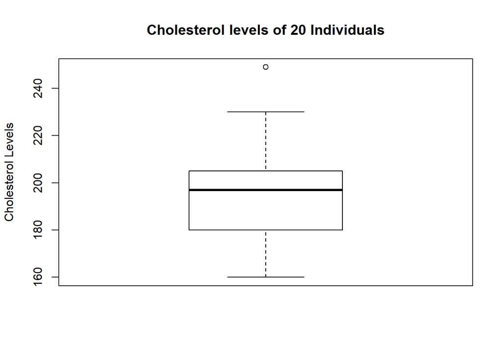

```r
boxplot(Q1, main = 'Cholesterol levels of 20 Individuals', ylab = 'Cholesterol Levels')
```

3. Identify the outlier(s) in the data using the IQR principle in the text book.

```r
sort(Q1)#升冪排列
```

```
##  [1] 160 164 166 178 178 182 182 184 188 196 198 198 198 200 204 206 212
## [18] 222 230 249
```

```r
quantile(Q1, na.rm = T)[2] - 1.5 * IQR(Q1, na.rm = T)#Outlier下界
```

```
##    25%
## 145.75
```

```r
quantile(Q1, na.rm = T)[4] + 1.5 * IQR(Q1, na.rm = T)#Outlier上界
```

```
##    75%
## 239.75
```

**小於146或是大於240即為Outliers，此題只有249為Outlier。**

4. Create a 5-number summary for these data.

```r
summary(Q1)
```

```
##    Min. 1st Qu.  Median    Mean 3rd Qu.    Max.
##   160.0   181.0   197.0   194.8   204.5   249.0
```

**上程式結果扣除mean，即為5-number summary**

5. How would you describe the shape of the data?

**由於極值出現在直方圖右邊，使得整張圖為右曳。**

# Q2

1. Between 62 kg and 65 kg.

```r
pnorm(65, mean = 65, sd = 2.7) - pnorm(62, mean = 65, sd = 2.7)
```

```
## [1] 0.3667397
```

**使用R運算，所得結果為0.3667397**

```r
Z65 = 0
Z62 = (62 - 65)/2.7
Z62
```

```
## [1] -1.111111
```

```r
0.5 - 0.1335
```

```
## [1] 0.3665
```

**查表後，Z65對應的機率為0.5，Z62對應的機率為0.1335，而得所求0.3665**

2. Less than 70 kg.

```r
pnorm(70, mean = 65, sd = 2.7)
```

```
## [1] 0.9679765
```

**使用R運算，所得結果為0.9679765**

```r
Z70 = (70 - 65)/2.7
Z70
```

```
## [1] 1.851852
```

**查表後，Z70對應的機率為0.9678，即為所求**

3. Greater than 60 kg.

```r
pnorm(60, mean = 65, sd = 2.7, lower.tail = F)
```

```
## [1] 0.9679765
```

**使用R運算，所得結果為0.9679765**

```r
Z60 = (60 - 65)/2.7
Z60
```

```
## [1] -1.851852
```

```r
1 - 0.0322
```

```
## [1] 0.9678
```

**查表後，Z60對應的機率為0.0322，1 - 0.0322 = 0.9678即為所求**

4. Either less than 60 kg or greater than 70 kg.

```r
pnorm(60, mean = 65, sd = 2.7) + pnorm(70, mean = 65, sd = 2.7, lower.tail = F)
```

```
## [1] 0.0640471
```

**使用R運算，所得結果為0.0640471**

```r
0.0322 * 2
```

```
## [1] 0.0644
```

**查表後，Z60對應的機率為0.0322，又因對稱性，0.0322 * 2 = 0.0644即為所求**

# Q3

1. 請估計 KP、DD、YY 三位候選人各自的得票率。

```r
KP = 0.6 * 0.4 + 0.4 * 0.5
KP
```

```
## [1] 0.44
```

```r
DD = 0.6 * 0.55 + 0.4 * 0.05
DD
```

```
## [1] 0.35
```

```r
YY = 0.6 * 0.05 + 0.4 * 0.45
YY
```

```
## [1] 0.21
```

**KP的得票率為0.44，DD的得票率為0.35，YY的得票率為0.21**

2. 若子問題(1)的分析結果，KP 的得票率勝過 YY，你想要設法提高非泛藍選 民對 YY 的支持度(亦即：票投 YY 的比例)，來提高 YY 的得票率。請問 要自目前的 45%再提高多少比例以上，YY 的得票率才會超越 KP？(假設 提高非泛藍選民對 YY 的支持度，會等量地減少非泛藍選民對 KP 的支持 度，但不會影響非泛藍選民對 DD 的支持度。)

設X為YY欲提高的支持度，根據題目說明，可以列出以下等式：  
`0.6 * 0.4 + 0.4(0.5 - x) = 0.6 * 0.05 + 0.4 * (0.45 + x)`  
最後解得 `X = 0.2875`

**YY需再提高非泛藍選民的支持度要超過0.2875**

# Q4

1. 你今日搭 W 航空公司班機，在起點機場誤點出發，估計在終點機場準點抵達的機率為何？

定義事件：

- A = 終點誤點
- AC = 終點準點
- B = 起點誤點
- BC = 起點準點

已知機率：

- P(A) = 0.1
- P(AC) = 0.9
- P(B|A) = 0.8
- P(BC|A) = 0.2
- P(BC|AC) = 0.9
- P(B|AC) = 0.1

假設變數：

| . | A | AC | . |
| --- | --- | --- | --- |
| **B** | y | x - y | x |
| **BC** | 0.1 - y | 0.9 - x +y | 1-x |
| . | 0.1 | 0.9 | . |

P(A)P(B|A) = P(A&B) = 0.1 * 0.8 = y  
P(AC)P(B|AC) = P(B&AC) = 0.9 * 0.1 = x - y  
解聯立得x = 0.17，y = 0.08  
所求即為P(AC|B) = P(B|AC)*P(AC)/P(B)

```r
0.1 * 0.9 / 0.17
```

```
## [1] 0.5294118
```

**所求即為0.5294118**

2. 你加入 W 航空公司尊榮會員，會員每次搭乘航班時，若在起點機場準點出 發，但在終點機場誤點抵達，則公司會賠償會員 100 美元。你加入會員後， 預計一生中會搭乘 200 次 W 航空航班，請用電腦模擬，估計這一生會收到來自 W 航空公司的誤點賠償金額的期望值

誤點與否為二項分布，期望值為np。 P(起點機場準點 & 終點機場誤點) = P(BC & A) = 0.1 - y = 0.02

```r
p = 0.02
200 * 100 * p
```

```
## [1] 400
```

**這一生會收到來自 W 航空公司的誤點賠償金額的期望值400美元**

# Q5

台北市 YouBike 系統目前有 400 個租借站，每天有 10,000 部公共自行車在系 統上運作，故障率是 1%。  
(1) 請繪製台北市 YouBike 系統每天故障車輛數機率分布圖。  
故障與否為二項分布。

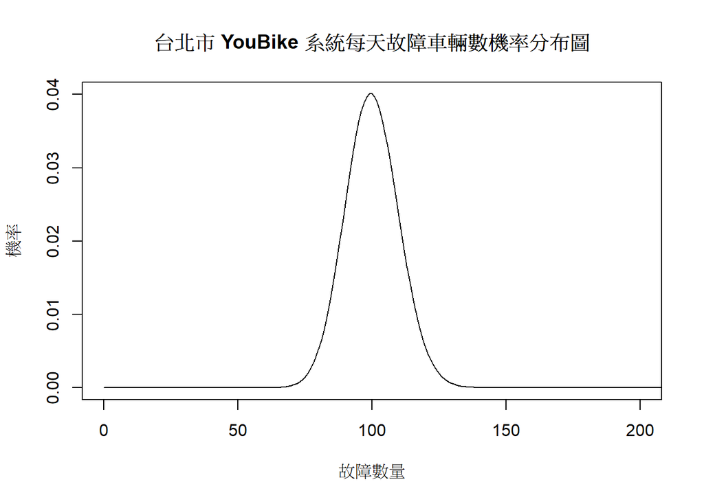

```r
# The Xs and Ys of the plot
xx = c(0:10000)
yy = dbinom(xx, size = 10000, prob = 0.01)

# Plotting
plot(x = xx, y = yy, type = "l", main = "台北市 YouBike 系統每天故障車輛數機率分布圖", xlab = '故障數量', ylab = '機率', xlim = c(0,200))
```

2. 若故障車輛隨機出現在租借站，且每個租借站最多只會出現一部故障車輛， 則每天有超過 30%的租借站出現故障車輛的機率為何？  
   超過120個租借站出現故障車輛即P(>120) = P(>=121) = 1 - P(<=120)。  
   每個租借站出現一台故障車的機率為10000*0.01/400 = 0.25  
   租借站是否出現故障車為二項分布。

```r
pbinom(120, size = 400, prob = 0.25, lower.tail = F)
```

```
## [1] 0.009970218
```

**每天有超過 30%的租借站出現故障車輛的機率為0.009970218**

3. 模擬在一年(365 天)中的每天故障車輛數，並估計在一年中，每天故障車輛 數屬於「離群值(outlier)」的日數。

```r
data <- rbinom(365, size = 10000, prob = 0.01)
Q1T <- quantile(data)[2] - 1.5 * IQR(data)
Q3T <- quantile(data)[4] + 1.5 * IQR(data)
count = 0
for (i in 1:365){
  if (data[i] < Q1T|data[i] > Q3T)
    count = count + 1
}
count
```

```
## [1] 1
```

**會超出離群值(outlier)的日數為上面(count)的天數**